# Individual assignment 2 - Louis Lemaître

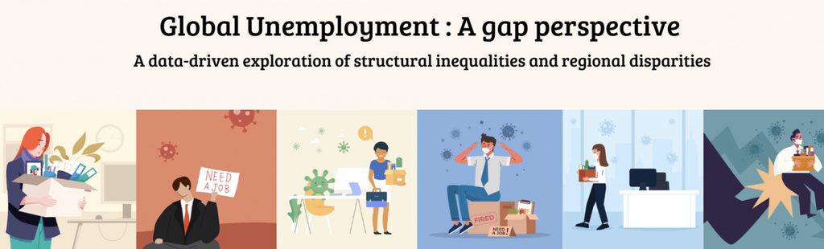

```python
from IPython.display import Image, display

url = "https://filmfrancophone.fr/ffa/up/2024/ggplot-image%20copy%201.jpg"
display(Image(url=url, width=1000, height=300))
```

Unemployment is one of the most pressing global challenges of our time. And it is not only a developing world issue. Even in high-income countries, political and economic shifts can trigger sudden spikes in joblessness. For example, economists have warned that the Trump administration’s efforts to downsize the U.S. federal government could temporarily push tens of thousands of workers—including contractors and bureaucrats—into unemployment.

A 2024 Urban Institute study estimated that laying off 75% of the federal workforce could raise unemployment rates by up to 2.5% in rural areas and 1% in major cities like Washington, D.C., highlighting how quickly employment trends can shift. But behind these fluctuations lies a deeper, more persistent divide: the gender gap. Around the world, young women consistently face higher unemployment rates than their male counterparts, regardless of geography or income level. Despite rising education levels and career aspirations, women are more likely to encounter structural and cultural barriers to employment—barriers that aren’t captured by headline economic figures alone.

```python
# Computation of the data and the GGplot options

from google.colab import drive
drive.mount('/content/drive')

import pandas as pd
edu_path = '/content/drive/My Drive/Data/education_data_prepared_1.csv'
meta_path = '/content/drive/My Drive/Data/metadata_prepared_1.csv'
unicef_path = '/content/drive/My Drive/Data/unicef_indicator_prepared_1.csv'

df_edu = pd.read_csv(edu_path, sep=';')
df_meta = pd.read_csv(meta_path, sep=';')
df_unicef = pd.read_csv(unicef_path, sep=';')
```

### Gender Unemployment Gap across the Globe

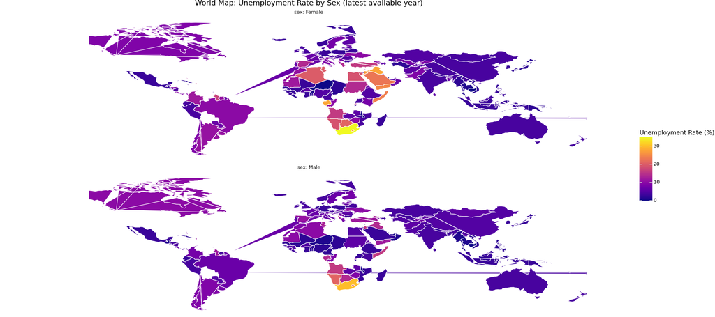

```python
import pandas as pd

world_data_sex_exploded = world_data_sex.explode(index_parts=True).reset_index()

world_data_sex_exploded['coords'] = world_data_sex_exploded['geometry'].apply(lambda x: x.exterior.coords.xy if x else ([], []))
world_data_sex_exploded['x'] = world_data_sex_exploded['coords'].apply(lambda x: x[0][0] if len(x[0]) > 0 else None)
world_data_sex_exploded['y'] = world_data_sex_exploded['coords'].apply(lambda x: x[1][0] if len(x[1]) > 0 else None)

def flatten_polygons(gdf):
    records = []
    for ix, row in gdf.iterrows():
        if row['geometry'] is not None and row['geometry'].geom_type == 'Polygon':
            xs, ys = row['geometry'].exterior.xy
            for x, y in zip(xs, ys):
                records.append({
                    'NAME': row['NAME'],
                    'obs_value': row['obs_value'],
                    'sex': row['sex'],
                    'x': x,
                    'y': y
                })
    return pd.DataFrame.from_records(records)

df_plot = flatten_polygons(world_data_sex_exploded)

df_plot_clean = df_plot.dropna(subset=['obs_value'])

p = (
    ggplot(df_plot_clean)
    + aes('x', 'y', group='NAME', fill='obs_value')
    + geom_polygon(color='white')
    + scale_fill_cmap("plasma")
    + labs(
        title="World Map: Unemployment Rate by Sex (latest available year)",
        fill="Unemployment Rate (%)"
    )
    + theme_void()
    + facet_wrap('~sex', labeller='label_both', ncol=1)

)
fig = p.draw()
fig.set_size_inches(18, 8)
fig.savefig("unemployment_map_vertical.png", dpi=150)
plt.close(fig)
display(Image(filename="unemployment_map_vertical.png"))
```

According to the ILO (2023), youth (15–24) are three times more likely to be unemployed than adults, with the highest concentration of unemployed youth in Africa and the Arab States. These patterns are exacerbated by underdeveloped labor markets, political instability, and lack of access to education or vocational training.

But beyond geography lies another crucial dimension: gender. Who are the people being left behind?

## 10 relevant countries in terms of Unemployment

According to the World Bank, “in many countries, especially in the MENA region, women’s participation in the labor force remains among the lowest globally—even when educational attainment is high.”

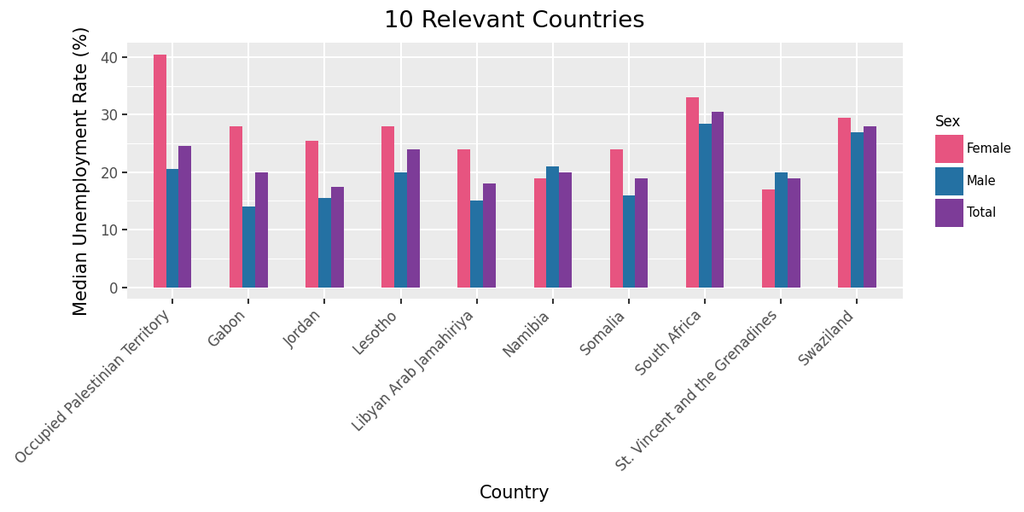

```python
import pandas as pd
from plotnine import *

# Data preparation
df_bar = (
    df_unicef
    .groupby(['country', 'sex'], as_index=False)
    .agg({'obs_value': 'median'})
)

# 2. 10 countries with the highest median
top_countries = (
    df_bar.groupby('country')['obs_value']
    .median()
    .sort_values(ascending=False)
    .head(10)
    .index.tolist()
)
df_bar = df_bar[df_bar['country'].isin(top_countries)]


p = (
    ggplot(df_bar, aes(x='country', y='obs_value', fill='sex'))
    + geom_bar(stat='identity', position='dodge')
    + labs(
        title='10 Relevant Countries',
        x='Country',
        y='Median Unemployment Rate (%)',
        fill='Sex'
    )
    + theme(axis_text_x=element_text(rotation=45, hjust=1))
)

# colour choices
my_colors = {
    'Male': '#2471A3',
    'Female': '#E75480',
    'Total': '#7D3C98'
}

p = (
    ggplot(df_bar, aes(x='country', y='obs_value', fill='sex'))
    + geom_bar(stat='identity', position='dodge', width=0.5)
    + scale_fill_manual(values=my_colors)
    + labs(
        title='10 Relevant Countries',
        x='Country',
        y='Median Unemployment Rate (%)',
        fill='Sex'
    )
    + theme(
        axis_text_x=element_text(rotation=45, hjust=1, size=8),
        axis_text_y=element_text(size=8),
        axis_title_x=element_text(size=10),
        axis_title_y=element_text(size=10),
        legend_title=element_text(size=8),
        legend_text=element_text(size=7)
    )
)

from IPython.display import Image, display

p.save("bar_chart.png", width=8, height=4, dpi=150)

display(Image(filename="bar_chart.png"))
```

[Support “Action SA” just here](https://www.actionsa.org.za/actionsa-concerned-as-worsening-unemployment-stats-reveal-42-6-of-south-africans-are-jobless/)

# **Unemployment Trends by Gender (2019–2023)**

2021 marks a critical year: female unemployment spiked dramatically, surpassing 10% globally—while male unemployment remained comparatively lower. COVID-19 disproportionately impacted sectors employing women (hospitality, retail, education, healthcare).

This shart shows that while the general trend improved post-2021, the gap between male and female youth unemployment persists.

```
FutureWarning: Calling float on a single element Series is deprecated and will raise a TypeError in the future. Use float(ser.iloc[0]) instead
```

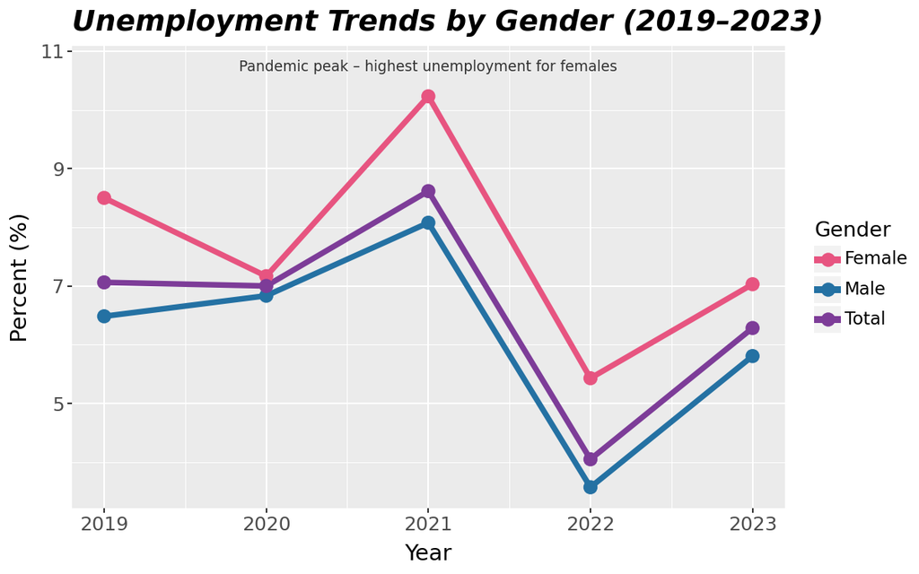

```python
import pandas as pd
from plotnine import *
from plotnine import annotate
from IPython.display import Image, display

df_line = (
    df_unicef
    .groupby(['time_period', 'sex'], as_index=False)
    .agg({'obs_value': 'mean'})
)

# colour choices
my_colors = {
    'Male': '#2471A3',
    'Female': '#E75480',
    'Total': '#7D3C98'
}

peak = df_line[(df_line['time_period'] == 2021) & (df_line['sex'] == 'Female')]

p = (
    ggplot(df_line, aes(x='time_period', y='obs_value', color='sex', group='sex'))
    + geom_line(size=2)
    + geom_point(size=4)
    + scale_color_manual(values=my_colors)
    + labs(
        title='Unemployment Trends by Gender (2019–2023)',
        x='Year', y='Percent (%)', color='Gender'
    )
    + theme(
        figure_size=(7, 5),
        axis_text=element_text(size=12),
        axis_title=element_text(size=14),
        legend_title=element_text(size=13),
        legend_text=element_text(size=11),
        plot_title=element_text(weight='bold', style='italic', size=18, ha='left')
    )
    + annotate(
        'text',
        x=2021,
        y=float(peak['obs_value']) + 0.5,
        label='Pandemic peak – highest unemployment for females',
        ha='center',
        size=9,
        color='#333333'
    )
)

p.save("unemployment_trends.png", width=8, height=5, dpi=150)
display(Image(filename="unemployment_trends.png"))
```

[figure not shown]

```python
from IPython.display import Image, display

url = "https://filmfrancophone.fr/ffa/up/2024/gg-plot-2.jpg"
display(Image(url=url, width=1000, height=300))
```

This reveals a crucial insight: wealth alone doesn’t guarantee inclusive labor markets. Structural inequalities - particularly gender-based—require policy-specific interventions.

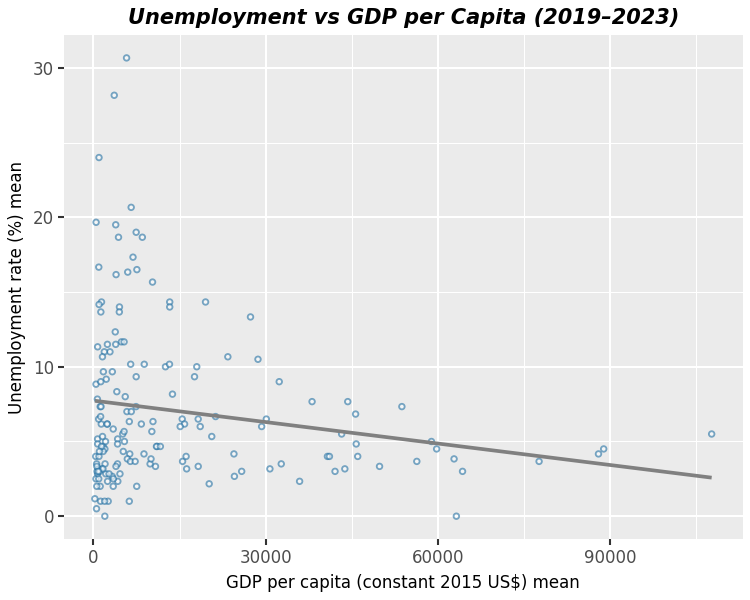

```python
df_scatter = (
    df_unicef
    .groupby('country', as_index=False)['obs_value'].mean()
    .rename(columns={'obs_value': 'unemployment_rate'})
)

df_gdp = (
    df_meta
    .groupby('country', as_index=False)['GDP per capita (constant 2015 US$)'].mean()
    .rename(columns={'GDP per capita (constant 2015 US$)': 'gdp_per_capita'})
)

# Merge of both
df_scatter = df_scatter.merge(df_gdp, on='country', how='inner')

from plotnine import *

p = (
    ggplot(df_scatter, aes(x='gdp_per_capita', y='unemployment_rate'))
    + geom_point(color='#2471A3', fill='white', size=1, alpha=0.6)
    + geom_smooth(method='lm', color='gray', linetype='solid', se=False)
    + labs(
        title='Unemployment vs GDP per Capita (2019–2023)',
        x='GDP per capita (constant 2015 US$) mean',
        y='Unemployment rate (%) mean'
    )
    + theme(
        figure_size=(6, 6),
        axis_text=element_text(size=8),
        axis_title=element_text(size=8),
        plot_title=element_text(weight='bold', style='italic', size=10)
    )
)

p.save("scatter_unemployment_gdp.png", width=5, height=4, dpi=150)
from IPython.display import Image, display
display(Image(filename="scatter_unemployment_gdp.png"))
```

# … When Education Isn’t Enough

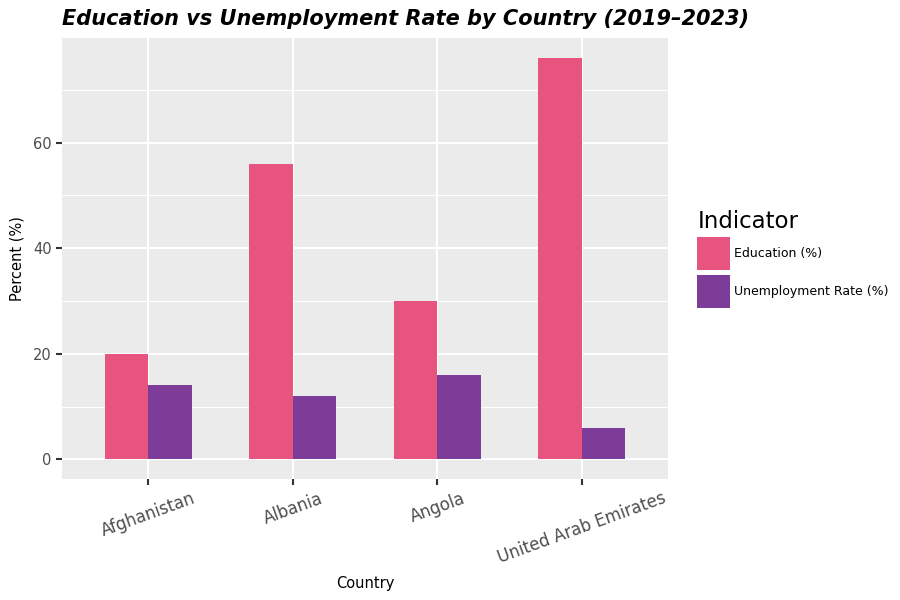

```python
df_grouped = (
    df_both_sample.groupby(['Country', 'Indicator'], as_index=False)['Value'].mean()
)
top_countries = df_grouped['Country'].unique()[:5]
df_plot = df_grouped[df_grouped['Country'].isin(top_countries)]


# colour choices
my_colors = {
    'Education (%)': '#E75480',  # pink
    'Unemployment Rate (%)': '#7D3C98'  # purple
}

# 5 countries
top_countries = df_both_sample['Country'].unique()[:5]
df_plot = df_both_sample[df_both_sample['Country'].isin(top_countries)]

# Filter against Andorra (which didn't work well)
df_both_sample_filtered = df_plot[df_plot['Country'] != 'Andorra']

# Plot
p = (
    ggplot(df_both_sample_filtered, aes(x='Country', y='Value', fill='Indicator'))
    + geom_bar(stat='identity', position='dodge', width=0.6)
    + scale_fill_manual(values=my_colors)
    + labs(
        title='Education vs Unemployment Rate by Country (2019–2023)',
        x='Country',
        y='Percent (%)',
    )
    + theme(
        axis_text_x=element_text(rotation=20, size=8),
        figure_size=(9, 6),
        axis_text=element_text(size=7),
        axis_title=element_text(size=7),
        plot_title=element_text(weight='bold', style='italic', size=10, ha='left'),
        legend_text=element_text(size=6)
    )
)

p.save("education_unemployment_chart.png", width=6, height=4, dpi=150)

from IPython.display import Image, display
display(Image(filename="education_unemployment_chart.png"))
```

In theory, higher education should protect against unemployment. In practice, it doesn’t guarantee job access—especially for young women.

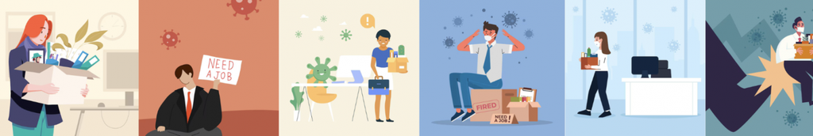

```python
from IPython.display import Image, display

url = "https://filmfrancophone.fr/ffa/up/2024/capture-d-ecran-2025-04-25-a-20-23-44.png"
display(Image(url=url, width=800, height=150))
```

## CONCLUSION : From Data to Policy

Across regions, the data reveals a persistent truth: young women are disproportionately excluded from the workforce, despite equal or higher levels of education.

[VIDEO : 5% of People in the World are Unemployed](https://www.youtube.com/watch?v=CFMomheJ8m8)